# RED WINE QUALITY EXPLORATION by Noopur Koshta

# Multivariate Analysis

### Talk about some of the relationships you observed in this part of the investigation. Were there features that strengthened each other in terms of looking at your feature(s) of interest?

- For free SO2 to remain in active state (where it can prevent oxidation of wines as well as build up micoorganisms), acidity should be high ie. pH should be low.
- For preventing acidic taste of wine, residual sugars must be adequately high to give sweeet taste to wine.
- Volatile acids do not contribute towards wine’s density, only the non-volatile acids do.

### Were there any interesting or surprising interactions between features?

The most surprising element was that highly acidic wines were of good quality, but then it turned out that higher the acidity, higher chnaces of free SO2 to remain in active state and thus preventing wines from bacteria and from getttig oxidized. Also, to counter the effect of acids, more residual sugar was added, which enhanced the density of wines. Thus, acids and residual sugar turned out to enhance the wines’ taste.

### OPTIONAL: Did you create any models with your dataset? Discuss the strengths and limitations of your model.

The mathematical models created suggests:

- Model 1: More residual sugar and lower acidity of red wines.
- Model 2: Amount of free SO2 in red wines

Strength of model: Wines satisfying such requirements are likely to be good quality wines. But to obtain the required relationship as per the 1st model is truely a bliss!

Weakness of model: According to 1st model, acidity can be lowered only upto certain limits, since we need to prevent oxidation as well microorganisms growth in wines. Also, free SO2 can be increased after some limitations otherwise taste of the wine may compromise. ——

# Final Plots and Summary

### Plot One

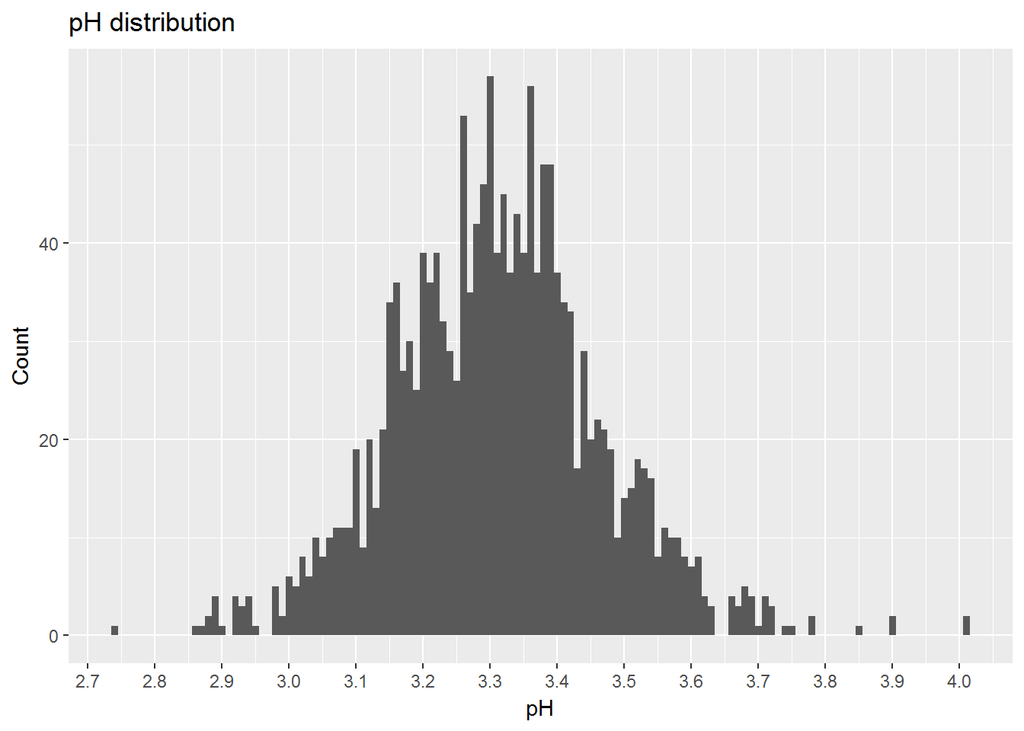

```
##
##    bad normal   good   best
##     16    606    120      0
```

### Description One

Even when the optimum pH range is 3.3 - 3.7, awful lot of the wines are having pH below 3.3. This may be since pH controls bacteria growth so to protect them from deteriorating over time, the pH had to be lowered with addition of the acids. Apart from that, since the mode is around 3.3, which suggests most wines with that pH, which is a good thing and also is inclined more towards the acidic scale in the desired pH range, which is also great since we can keep microorganisms growth at bay for longer time.

### Plot Two

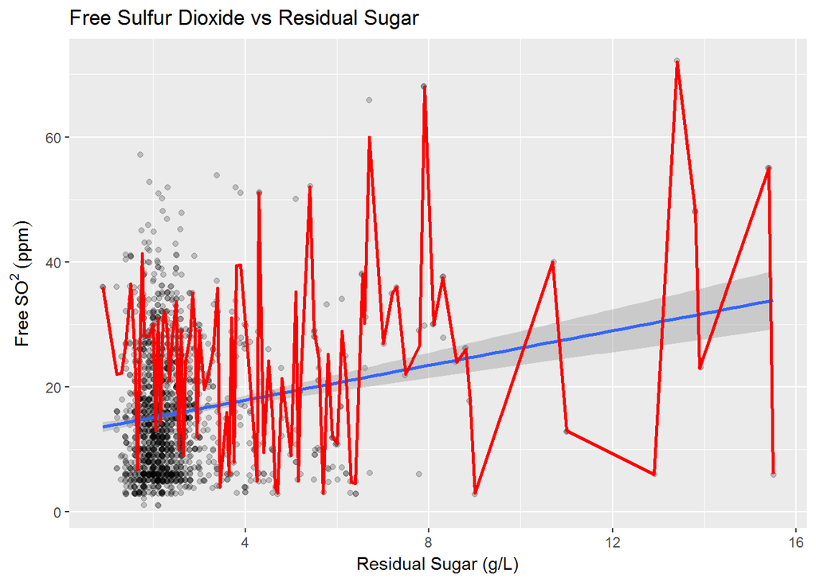

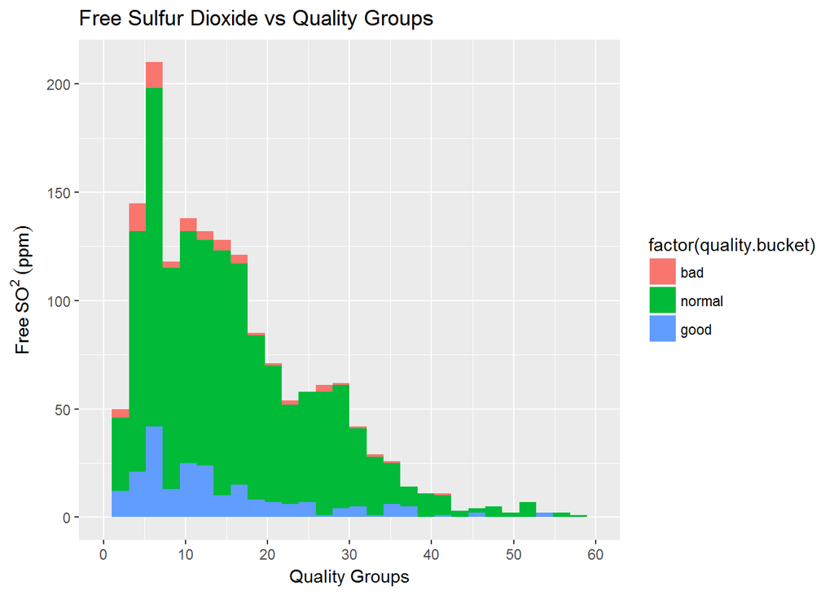

### Description Two

With the increase in residual sugar, more free SO2 is required since it binds with chemicals in wine. But good quality wines are comparitively lower in free SO2 levels, this may be because with time residual sugar might have bound with free SO2. But then what proves them the “good” quality wines.

### Plot Three

```
##
##   3   4   5   6   7   8
##  10  53 681 638 199  18
```

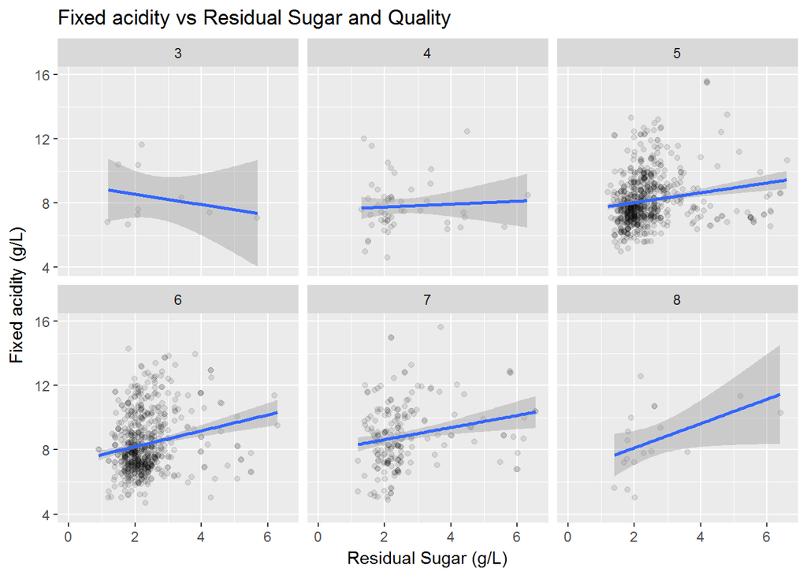

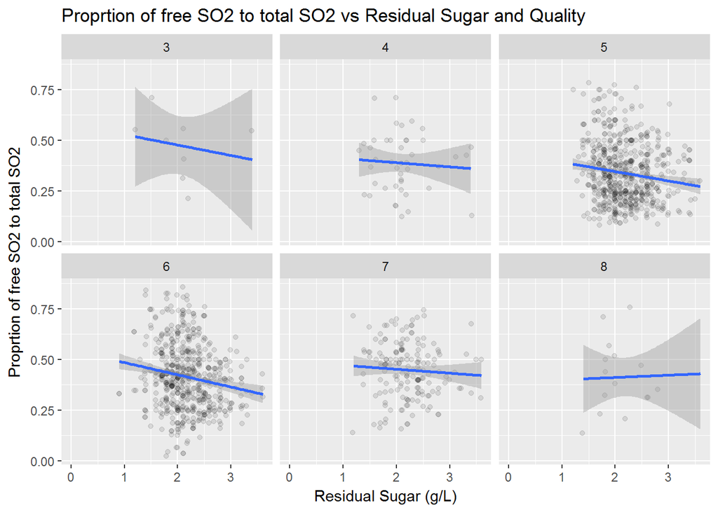

### Description Three

With increasing acidity, residual sugar is increased, thus preventing bacteria growth. Also, there is a slight positive correlation in quality 8 wines in terms of proportion of free SO2 vs residual sugar, thus we can say that overall wines of good quality can be reinjected with free SO2 to again maintain their position in respective quality bins, without compromising taste upto a certain extent.

# Reflection

> **Tip**: Here’s the final step! Reflect on the exploration you performed and the insights you found. What were some of the struggles that you went through? What went well? What was surprising? Make sure you include an insight into future work that could be done with the dataset.

This dataset contained 1,599 observations of Portuguese Vinho Verde red wines. Each wine received a quality rating (bad, normal, good) and had information on 11 different chemical attributes. My main interest in exploring this dataset was to try to learn about how the chemical attributes of a wine might be associated with its quality rating. Through a combination of graphical and statistical analysis, I was able to assess the different relationships between the predictor and outcome variable (quality in this case).

Major interest of exploration were the following atributes:

- Free SO2
- Volatile as well as non-volatile components of acid content in the wine
- Density
- Residual Sugar

All the above factors had weak negative correlation with quality, except the non-volatile acids, but then I explored the relationship of each of the attributes with each other and found out what made the correlation so overall. And the reason for such a correlation was that most of the wines were of normal or poor quality, hence driving the correlation according to them.

The surprising elements at first were high acidity levels of good quality wines, but then this relation with free SO2 and residual sugars solved the mystery.

Going a bit long way to examine each attribute was worth, since that helped me understand the importance of each chemical in the wine making. Extending the exploration phase, we can compare this dataset alongside the white wine dataset, and compare how different their chemical composotion is and how they are too classified into different wine quality ratings. Also, we can extend this exploration to figure out that even the good quality wine composition apart from being good to taste are healthy to consume or not; what chemicals composition can have bad health efffects in the future. And thus what amount of consumption of wine is healthy.

References:

- http://www.scielo.br/scielo.php?script=sci_arttext&pid=S0101-20612015000100095
- http://winefolly.com/tutorial/the-lightest-to-the-strongest-wine/
- https://www.accuvin.com/wp-content/uploads/2015/04/How-SO2-and-pH-are-Linked.pdf
- http://www.wineperspective.com/wine-acidity/
- http://extension.psu.edu/food/enology/wine-production/wine-made-easy-fact-sheets/volatile-acidity-in-wine
- https://psuwineandgrapes.wordpress.com/2015/02/20/is-your-wine-slowly-turning-into-vinegar-basic-information-about-volatile-acidity/
- http://waterhouse.ucdavis.edu/whats-in-wine/
- http://winefolly.com/tutorial/how-to-taste-red-wine/
- http://webcache.googleusercontent.com/search?q=cache:http://images.alfresco.advanstar.com/alfresco_images/pharma/2014/08/22/f8ebccf3-6590-401c-afee-85236db18352/article-45017.pdf&gws_rd=cr&ei=1cdNWbnSCMXavgThjKX4Bw
- http://gwi.missouri.edu/publications/2013spring.pdf
- http://www.morebeer.com/web_files/morebeer.com/files/Manuals/so2.pdf
- http://winefolly.com/tutorial/how-to-taste-red-wine/
- https://winemakermag.com/547-phiguring-out-ph
- https://winemakermag.com/501-measuring-residual-sugar-techniques